# Climate Trend Analysis Demo

Alicia Fennell, Jordan Isken, Gavriella Keyles

4/6/2021

## R Markdown

Couple of brief notes: - I have used the ‘setwd’ command to change the working directory to the location where my data file is stored on my local machine. You’ll need to change that path to the appropriate directory on your own computer.

- The read.table command loads the CSV file provided by NCDC into a table structure in R, here called ‘clim’; the as.Date command then transforms the DATE field in that table into an R-formatted date array that R knows how to do things with. ##################

```r
library(lubridate)
```

```r
library(ggplot2)
library(tidyverse)
library(chron)
library(janitor)
denali_data <-  read.table("denali_data.csv",fill=TRUE,sep=',',header=T) %>%
  clean_names() %>%
  mutate(date = ymd(date)) %>%
  filter(year(date) < 2021)
```

Now that we’ve read in the data, the next step is quality checking! Let’s make a plot to see what data are missing.

Lets start with daily data of air temperature

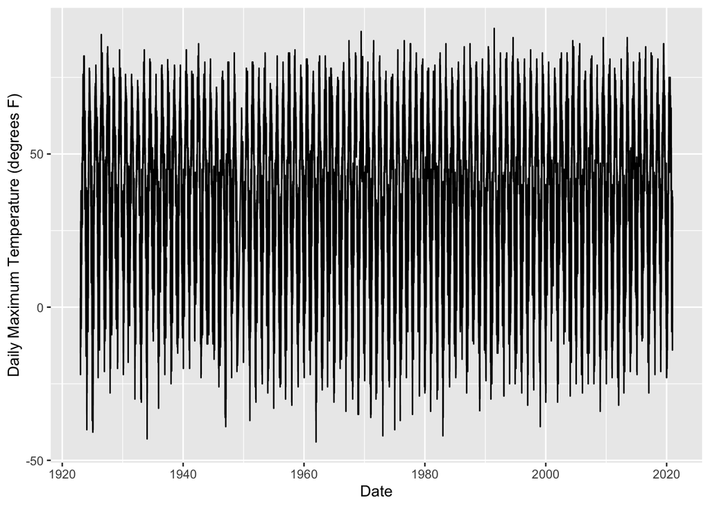

```r
ggplot(denali_data, aes(date, tmax))+
  geom_line() +
  labs(y="Daily Maximum Temperature (degrees F)", x="Date")
```

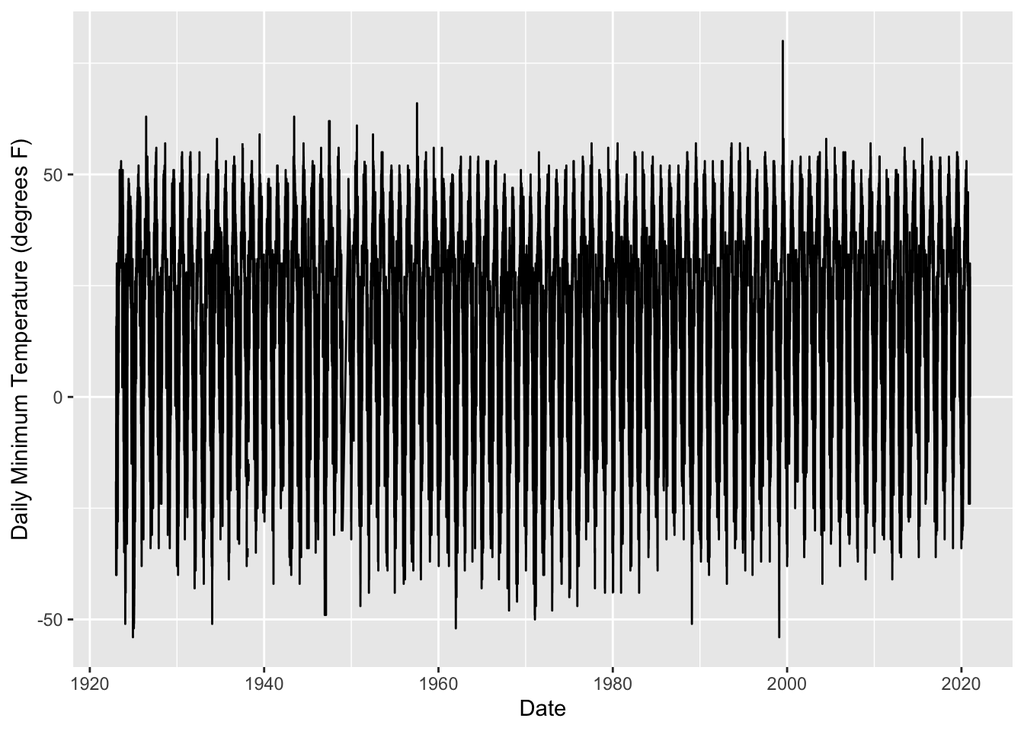

```r
ggplot(denali_data, aes(date, tmin))+
  geom_line() +
  labs(y="Daily Minimum Temperature (degrees F)", x="Date")
```

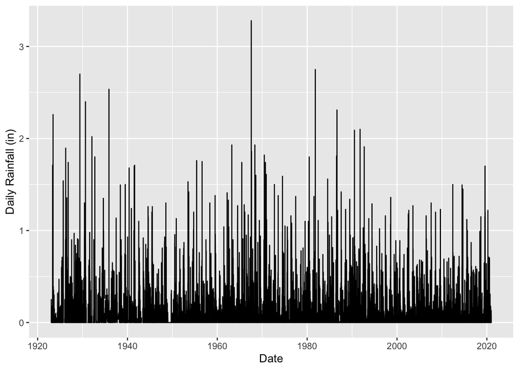

```r
ggplot(denali_data, aes(date, prcp))+
  geom_line()+
  labs(y="Daily Rainfall (in)", x="Date")
```

Some values are “NA” in temperature and precipitation; these have been trimmed automatically by ggplot, but this may not be the case for all functions. In general, you’ll want to check meta data to see how missing data is labelled: -999 or NA are common choices.

To fill - if < 0.5 percent of data is missing there are some very simple ways to fill but you must remember that you are doing this!!!

- **Temperature** Average of the previous and following day
- **Precip** For dry places like the Sierra, assume no rain where data is missing (This may not be a good assumption in other places! be careful.)

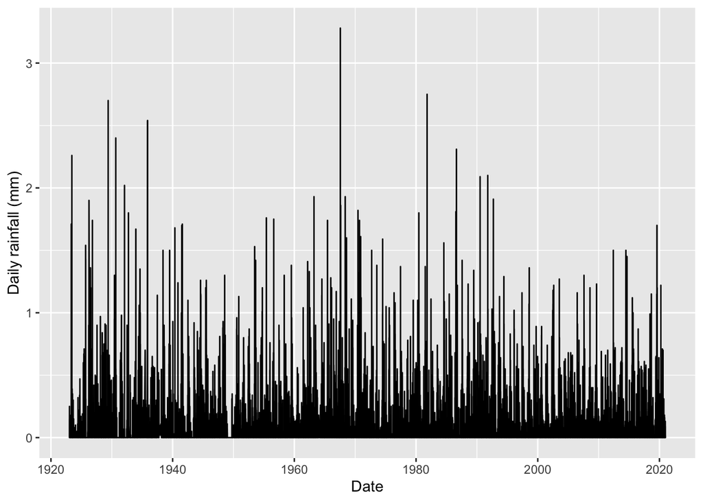

```r
# find the row with missing data
# fillrow = which(is.na(denali_data$prcp))
# fillrow
# denali_data$prcp[fillrow]=0
# replot to make sure it works

# remove NAs from precipitation
prcp_subset <- denali_data %>%
  filter(!(is.na(prcp)))

# plot it again
ggplot(prcp_subset, aes(date, prcp))+
  geom_line()+
  labs(y="Daily rainfall (mm)", x="Date")
```

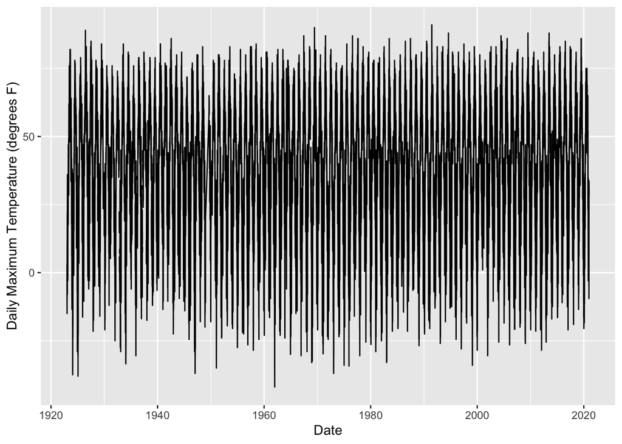

```r
# find rows with missing data
# temperature
fillrow = which(is.na(denali_data$tmax) | denali_data$tmax < 40)
fillrow = fillrow[2:length(fillrow)]
denali_data$tmax[fillrow]=(denali_data$tmax[fillrow+1]+denali_data$tmax[fillrow-1])/2
ggplot(denali_data, aes(date, denali_data$tmax))+geom_line()+ labs(y="Daily Maximum Temperature (degrees F)", x="Date")
```

```r
# temp_subset <- denali_data %>%
#   mutate(tmax = replace(is.na(tmax), 0)) %>%
#   mutate(tmax = ifelse(is.na(tmax), ((lag(tmax)+lead(tmax))/2), tmax))
```

**Is there a trend?**

Trends can be ‘swamped’ by variation; in this case, the seasonal cycle is quite large. We also need to consider autocorrelation!

So here let’s try doing some aggregation to reduce the noise. As a simple example, we can try annual averages.

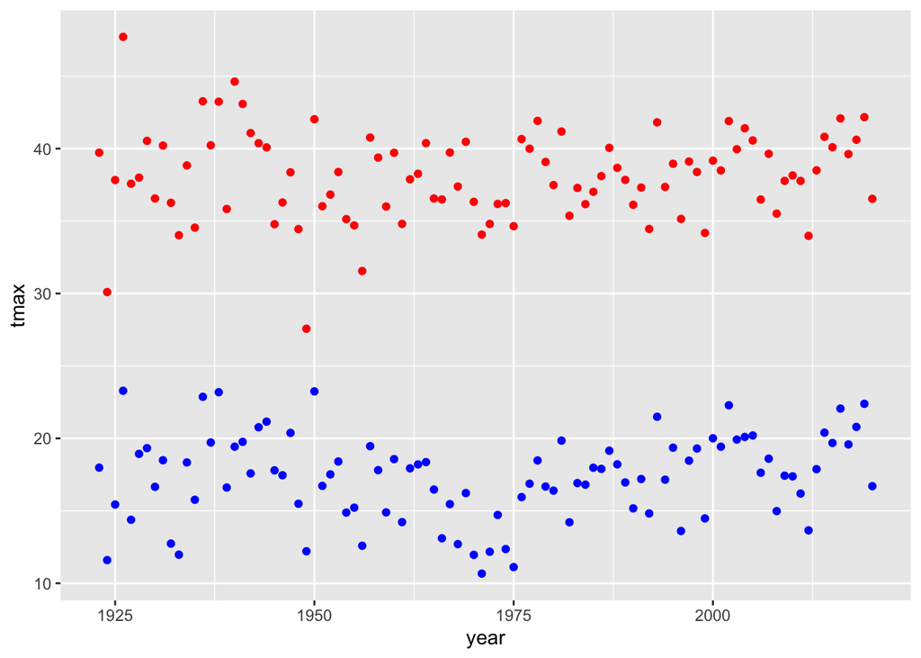

```r
denali_agg <-  denali_data %>%
  group_by(year(date)) %>%
  summarize(tmax=mean(tmax, na.rm = TRUE), tmin=mean(tmin, na.rm = TRUE), precip=sum(prcp, na.rm = TRUE)) %>%
  rename(year = 1)

ggplot(denali_agg, aes(x=year, tmax))+
  geom_point(col="red")+
  scale_y_continuous(limits=c(min(denali_agg$tmin), max(denali_agg$tmax)))+
  geom_point(data=denali_agg, aes(x=year, tmin), col="blue")
```

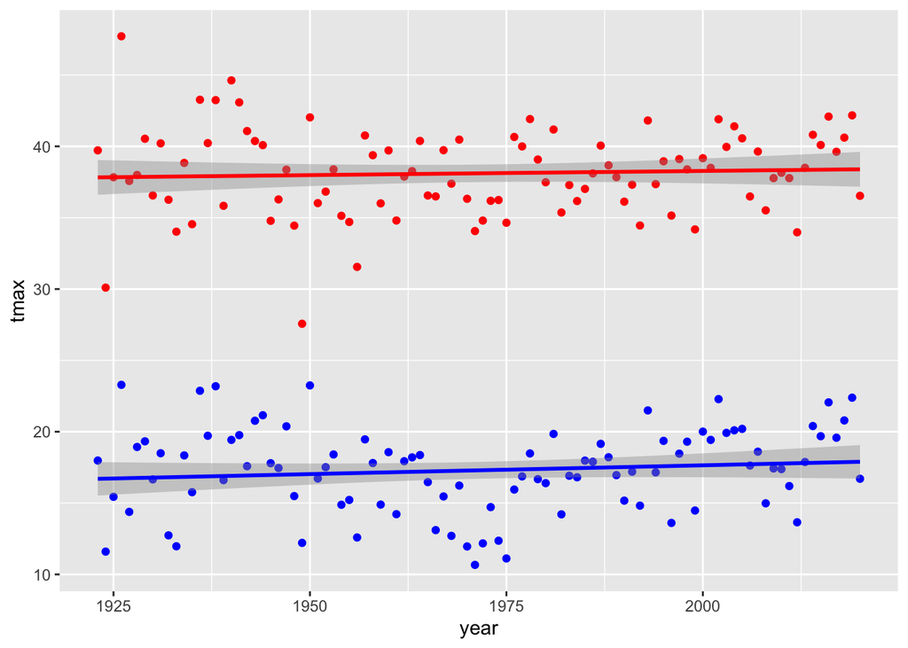

```r
ggplot(denali_agg, aes(x=year, tmax))+
  geom_point(col="red")+
  scale_y_continuous(limits=c(min(denali_agg$tmin), max(denali_agg$tmax)))+
  geom_point(data=denali_agg, aes(x=year, tmin), col="blue")+
  stat_smooth(method="lm", col="red")+
  stat_smooth(data=denali_agg, aes(x=year,tmin), col="blue", method="lm")
```

Notice the different behavior of the min and max temperatures!

OK now let’s put a trend line on this thing.

```r
# now lets add a trend line
```

Now let’s calculate the slope (or how quickly temperatures are rising; we do this with linear regression)

```r
res=lm(tmin~year, data=denali_agg)
summary(res)
```

```
##
## Call:
## lm(formula = tmin ~ year, data = denali_agg)
##
## Residuals:
##     Min      1Q  Median      3Q     Max
## -6.6218 -1.8493  0.2459  1.8340  6.5503
##
## Coefficients:
##             Estimate Std. Error t value Pr(>|t|)
## (Intercept) -6.97293   20.74308  -0.336    0.737
## year         0.01231    0.01052   1.170    0.245
##
## Residual standard error: 2.946 on 96 degrees of freedom
## Multiple R-squared:  0.01406,    Adjusted R-squared:  0.00379
## F-statistic: 1.369 on 1 and 96 DF,  p-value: 0.2449
```

```r
confint(res,"year", level=0.95)
```

```
##            2.5 %     97.5 %
## year -0.00857316 0.03319246
```

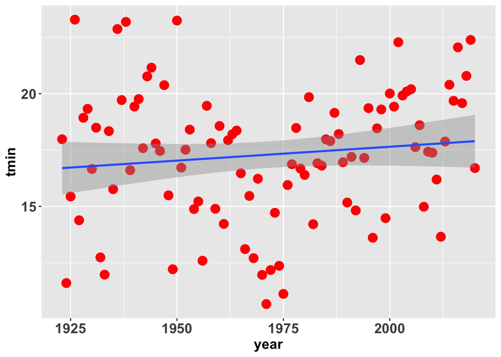

```r
ggplot(denali_agg, aes(x=year, y=tmin)) + stat_summary(fun.y="mean", geom="point", col="red", size=4)+theme(axis.text=element_text(size=14, face="bold"), axis.title=element_text(size=14, face="bold")) + geom_smooth(method="lm")
```

The slope on a linear regression between Tmin and wy is the rate of increase in Tmin (mean annual daily minimum temperature).

Let’s do the same analysis for the MAXIMUM temperature now…

```r
res=lm(tmax~year, data=denali_agg)
summary(res)
```

```
##
## Call:
## lm(formula = tmax ~ year, data = denali_agg)
##
## Residuals:
##      Min       1Q   Median       3Q      Max
## -10.4120  -1.9227   0.0586   2.2072   9.8692
##
## Coefficients:
##              Estimate Std. Error t value Pr(>|t|)
## (Intercept) 26.619691  21.560269   1.235    0.220
## year         0.005828   0.010935   0.533    0.595
##
## Residual standard error: 3.062 on 96 degrees of freedom
## Multiple R-squared:  0.00295,    Adjusted R-squared:  -0.007436
## F-statistic: 0.2841 on 1 and 96 DF,  p-value: 0.5953
```

```r
confint(res,"year", level=0.95)
```

```
##            2.5 %     97.5 %
## year -0.01587755 0.02753345
```

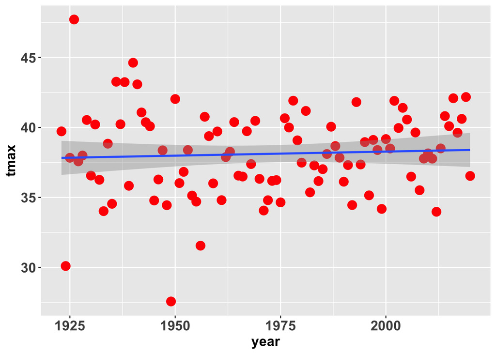

```r
ggplot(denali_agg, aes(x=year, y=tmax)) + stat_summary(fun.y="mean", geom="point", col="red", size=4)+theme(axis.text=element_text(size=14, face="bold"), axis.title=element_text(size=14, face="bold")) + geom_smooth(method="lm")
```

We might also cut the data into specific periods and see how the slope is changing as a function of time.

```r
# early portion
res_early=lm(tmin~year, data=subset(denali_agg, denali_agg$year %in% c(1925:1970)))
summary(res_early)
```

```
##
## Call:
## lm(formula = tmin ~ year, data = subset(denali_agg, denali_agg$year %in%
##     c(1925:1970)))
##
## Residuals:
##    Min     1Q Median     3Q    Max
## -6.300 -1.893  0.224  1.958  6.166
##
## Coefficients:
##              Estimate Std. Error t value Pr(>|t|)
## (Intercept) 153.90709   63.85647    2.41   0.0202 *
## year         -0.07017    0.03279   -2.14   0.0379 *
## ---
## Signif. codes:  0 '***' 0.001 '**' 0.01 '*' 0.05 '.' 0.1 ' ' 1
##
## Residual standard error: 2.952 on 44 degrees of freedom
## Multiple R-squared:  0.09427,    Adjusted R-squared:  0.07369
## F-statistic:  4.58 on 1 and 44 DF,  p-value: 0.03793
```

```r
confint(res_early,"year", level=0.90)
```

```
##             5 %        95 %
## year -0.1252601 -0.01507675
```

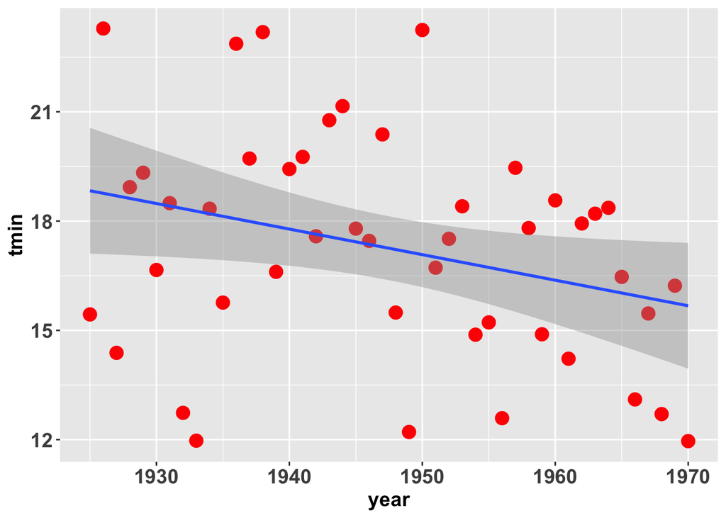

```r
ggplot(subset(denali_agg, denali_agg$year %in% c(1925:1970)), aes(x=year, y=tmin)) + stat_summary(fun.y="mean", geom="point", col="red", size=4)+theme(axis.text=element_text(size=14, face="bold"), axis.title=element_text(size=14, face="bold")) + geom_smooth(method="lm")
```

```r
# late portion
res_late=lm(tmin~year, data=subset(denali_agg, denali_agg$year %in% c(1970:2020)))
summary(res_late)
```

```
##
## Call:
## lm(formula = tmin ~ year, data = subset(denali_agg, denali_agg$year %in%
##     c(1970:2020)))
##
## Residuals:
##     Min      1Q  Median      3Q     Max
## -5.5533 -1.6424  0.6973  1.6830  4.3876
##
## Coefficients:
##               Estimate Std. Error t value Pr(>|t|)
## (Intercept) -203.25402   45.53479  -4.464 4.73e-05 ***
## year           0.11057    0.02282   4.844 1.32e-05 ***
## ---
## Signif. codes:  0 '***' 0.001 '**' 0.01 '*' 0.05 '.' 0.1 ' ' 1
##
## Residual standard error: 2.399 on 49 degrees of freedom
## Multiple R-squared:  0.3238, Adjusted R-squared:   0.31
## F-statistic: 23.47 on 1 and 49 DF,  p-value: 1.316e-05
```

```r
confint(res_late,"year", level=0.90)
```

```
##             5 %      95 %
## year 0.07230143 0.1488321
```

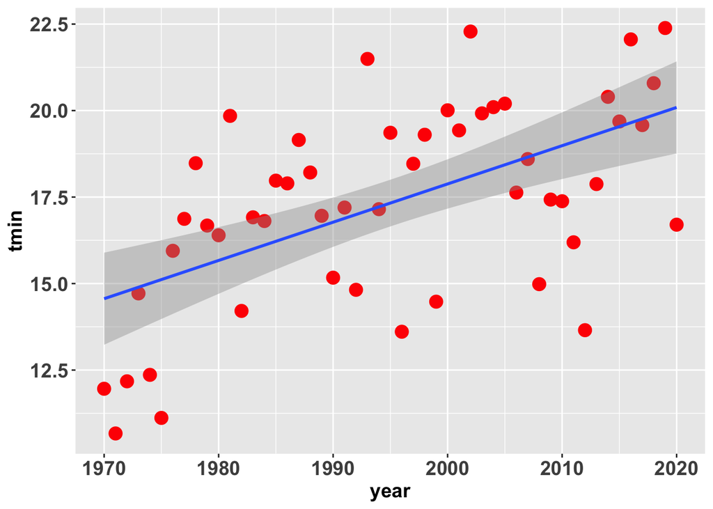

```r
ggplot(subset(denali_agg, denali_agg$year %in% c(1970:2020)), aes(x=year, y=tmin)) + stat_summary(fun.y="mean", geom="point", col="red", size=4)+theme(axis.text=element_text(size=14, face="bold"), axis.title=element_text(size=14, face="bold")) + geom_smooth(method="lm")
```

```r
# since 2000
res_recent=lm(tmin~year, data=subset(denali_agg, denali_agg$year %in% c(2000:2020)))
summary(res_recent)
```

```
##
## Call:
## lm(formula = tmin ~ year, data = subset(denali_agg, denali_agg$year %in%
##     c(2000:2020)))
##
## Residuals:
##     Min      1Q  Median      3Q     Max
## -5.2481 -1.4993  0.7224  1.2391  3.5449
##
## Coefficients:
##               Estimate Std. Error t value Pr(>|t|)
## (Intercept)  36.075995 172.978115   0.209    0.837
## year         -0.008536   0.086058  -0.099    0.922
##
## Residual standard error: 2.388 on 19 degrees of freedom
## Multiple R-squared:  0.0005176,  Adjusted R-squared:  -0.05209
## F-statistic: 0.009839 on 1 and 19 DF,  p-value: 0.922
```

```r
confint(res_recent,"year", level=0.90)
```

```
##             5 %      95 %
## year -0.1573426 0.1402701
```

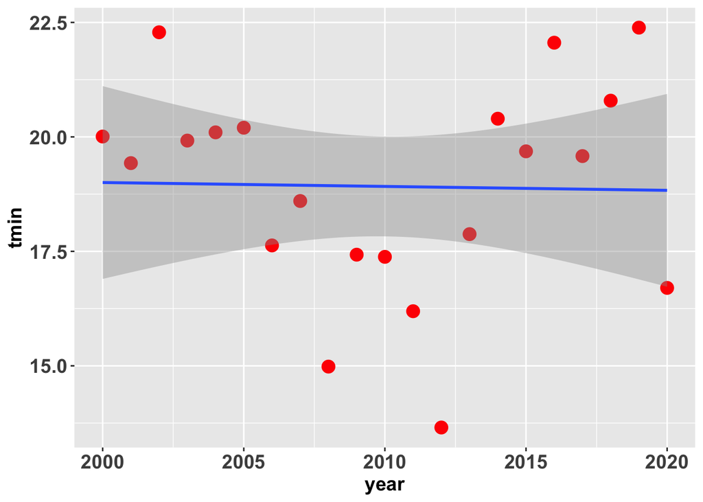

```r
ggplot(subset(denali_agg, denali_agg$year %in% c(2000:2020)), aes(x=year, y=tmin)) + stat_summary(fun.y="mean", geom="point", col="red", size=4)+theme(axis.text=element_text(size=14, face="bold"), axis.title=element_text(size=14, face="bold")) + geom_smooth(method="lm")
```

Repeat for maximums

```r
# early portion
res_early=lm(tmax~year, data=subset(denali_agg, denali_agg$year %in% c(1925:1970)))
summary(res_early)
```

```
##
## Call:
## lm(formula = tmax ~ year, data = subset(denali_agg, denali_agg$year %in%
##     c(1925:1970)))
##
## Residuals:
##      Min       1Q   Median       3Q      Max
## -10.4824  -2.4008   0.0759   2.2081   8.3745
##
## Coefficients:
##              Estimate Std. Error t value Pr(>|t|)
## (Intercept) 147.38360   75.31469   1.957   0.0567 .
## year         -0.05610    0.03867  -1.451   0.1540
## ---
## Signif. codes:  0 '***' 0.001 '**' 0.01 '*' 0.05 '.' 0.1 ' ' 1
##
## Residual standard error: 3.482 on 44 degrees of freedom
## Multiple R-squared:  0.04564,    Adjusted R-squared:  0.02395
## F-statistic: 2.104 on 1 and 44 DF,  p-value: 0.154
```

```r
confint(res_early,"year", level=0.90)
```

```
##             5 %        95 %
## year -0.1210751 0.008879266
```

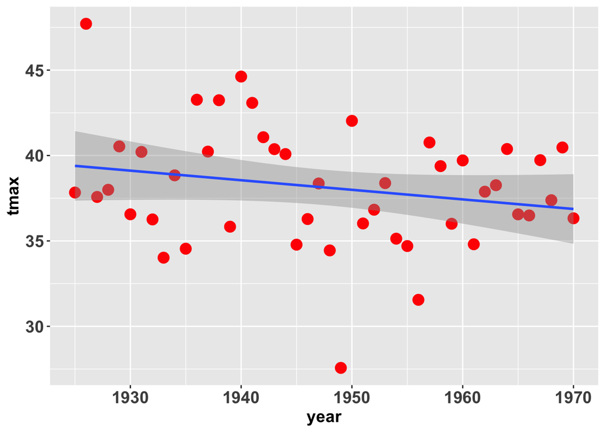

```r
ggplot(subset(denali_agg, denali_agg$year %in% c(1925:1970)), aes(x=year, y=tmax)) + stat_summary(fun.y="mean", geom="point", col="red", size=4)+theme(axis.text=element_text(size=14, face="bold"), axis.title=element_text(size=14, face="bold")) + geom_smooth(method="lm")
```

```r
# late portion
res_late=lm(tmax~year, data=subset(denali_agg, denali_agg$year %in% c(1970:2020)))
summary(res_late)
```

```
##
## Call:
## lm(formula = tmax ~ year, data = subset(denali_agg, denali_agg$year %in%
##     c(1970:2020)))
##
## Residuals:
##    Min     1Q Median     3Q    Max
## -5.057 -1.335  0.013  1.530  4.587
##
## Coefficients:
##              Estimate Std. Error t value Pr(>|t|)
## (Intercept) -61.99535   43.05519  -1.440   0.1563
## year          0.05021    0.02158   2.327   0.0242 *
## ---
## Signif. codes:  0 '***' 0.001 '**' 0.01 '*' 0.05 '.' 0.1 ' ' 1
##
## Residual standard error: 2.269 on 49 degrees of freedom
## Multiple R-squared:  0.09949,    Adjusted R-squared:  0.08111
## F-statistic: 5.414 on 1 and 49 DF,  p-value: 0.02416
```

```r
confint(res_late,"year", level=0.90)
```

```
##             5 %       95 %
## year 0.01403107 0.08639422
```

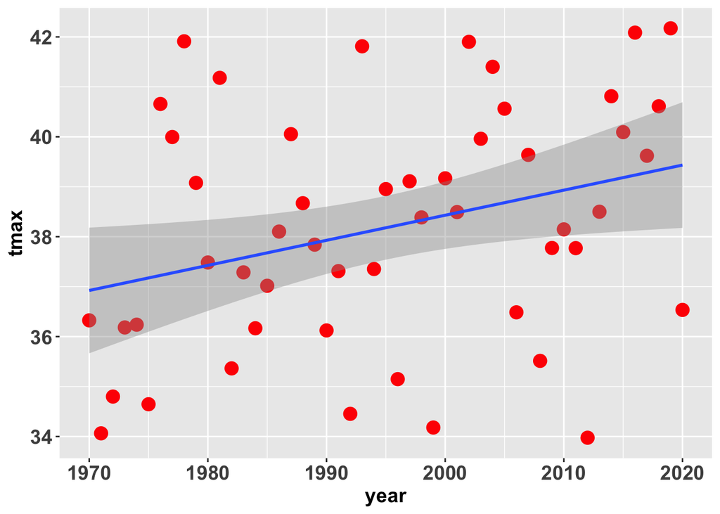

```r
ggplot(subset(denali_agg, denali_agg$year %in% c(1970:2020)), aes(x=year, y=tmax)) + stat_summary(fun.y="mean", geom="point", col="red", size=4)+theme(axis.text=element_text(size=14, face="bold"), axis.title=element_text(size=14, face="bold")) + geom_smooth(method="lm")
```

```r
# since 2000
res_recent=lm(tmax~year, data=subset(denali_agg, denali_agg$year %in% c(2000:2020)))
summary(res_recent)
```

```
##
## Call:
## lm(formula = tmax ~ year, data = subset(denali_agg, denali_agg$year %in%
##     c(2000:2020)))
##
## Residuals:
##     Min      1Q  Median      3Q     Max
## -5.1478 -1.3234  0.4543  1.5001  2.9891
##
## Coefficients:
##              Estimate Std. Error t value Pr(>|t|)
## (Intercept) 2.180e+01  1.652e+02   0.132    0.896
## year        8.611e-03  8.217e-02   0.105    0.918
##
## Residual standard error: 2.28 on 19 degrees of freedom
## Multiple R-squared:  0.0005777,  Adjusted R-squared:  -0.05202
## F-statistic: 0.01098 on 1 and 19 DF,  p-value: 0.9176
```

```r
confint(res_recent,"year", level=0.90)
```

```
##            5 %      95 %
## year -0.133478 0.1507008
```

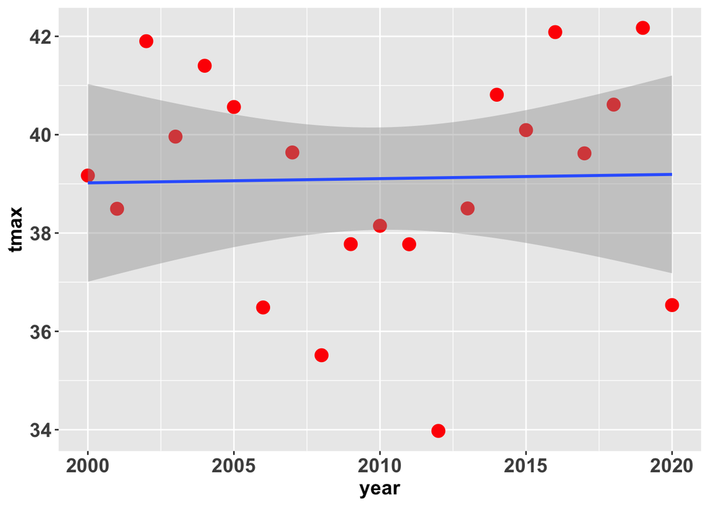

```r
ggplot(subset(denali_agg, denali_agg$year %in% c(2000:2020)), aes(x=year, y=tmax)) + stat_summary(fun.y="mean", geom="point", col="red", size=4)+theme(axis.text=element_text(size=14, face="bold"), axis.title=element_text(size=14, face="bold")) + geom_smooth(method="lm")
```

Regression assumes a linear relationship - and normally distributed data - sometimes that isn’t true, we can use non-parameteric tests to look for trends. In these cases, the Mann-Kendall test is commonly used.

tau ranges from -1 to 1 and denotes the “strength” of the trend; p-value denotes significance. Strength however can not be interpreted as slope!

```r
library(Kendall)
MannKendall(denali_agg$tmin)
```

```
## tau = 0.097, 2-sided pvalue =0.15799
```

```r
MannKendall(denali_agg$tmax)
```

```
## tau = 0.0562, 2-sided pvalue =0.41425
```

```r
MannKendall(denali_agg$precip)
```

```
## tau = 0.214, 2-sided pvalue =0.0018563
```

We might also look at difference in means (or variance) between the two periods …Using

T-test or Rank-Sum if we think data is not normally distributed

```r
t.test(subset(denali_agg$tmin, denali_agg$year %in% 1925:1970), subset(denali_agg$tmin, denali_agg$year %in% 1970:2020))
```

```
##
##  Welch Two Sample t-test
##
## data:  subset(denali_agg$tmin, denali_agg$year %in% 1925:1970) and subset(denali_agg$tmin, denali_agg$year %in% 1970:2020)
## t = -0.11964, df = 92.508, p-value = 0.905
## alternative hypothesis: true difference in means is not equal to 0
## 95 percent confidence interval:
##  -1.277549  1.132369
## sample estimates:
## mean of x mean of y
##  17.25405  17.32664
```

```r
t.test(subset(denali_agg$tmax, denali_agg$year %in% 1925:1970), subset(denali_agg$tmax, denali_agg$year %in% 1970:2020))
```

```
##
##  Welch Two Sample t-test
##
## data:  subset(denali_agg$tmax, denali_agg$year %in% 1925:1970) and subset(denali_agg$tmax, denali_agg$year %in% 1970:2020)
## t = -0.074588, df = 77.505, p-value = 0.9407
## alternative hypothesis: true difference in means is not equal to 0
## 95 percent confidence interval:
##  -1.273119  1.181177
## sample estimates:
## mean of x mean of y
##  38.13291  38.17888
```

```r
t.test(subset(denali_agg$precip, denali_agg$year %in% 1925:1970), subset(denali_agg$precip, denali_agg$year %in% 1970:2020))
```

```
##
##  Welch Two Sample t-test
##
## data:  subset(denali_agg$precip, denali_agg$year %in% 1925:1970) and subset(denali_agg$precip, denali_agg$year %in% 1970:2020)
## t = -1.7168, df = 85.208, p-value = 0.08964
## alternative hypothesis: true difference in means is not equal to 0
## 95 percent confidence interval:
##  -3.1168806  0.2282873
## sample estimates:
## mean of x mean of y
##  14.12217  15.56647
```

```r
# create a variable
denali_data.byseason <- denali_data %>%
  mutate(season = ifelse(month(date) %in% c(12,1,2), 1, ifelse(month(date) %in% c(3:5),2, ifelse(month(date) %in% c(6:8),3,4))))

denali_data.byseason <-  denali_data.byseason %>%
  group_by(year(date),season) %>%
  summarize(tmax=mean(tmax), tmin=mean(tmin), precip=sum(prcp))
```

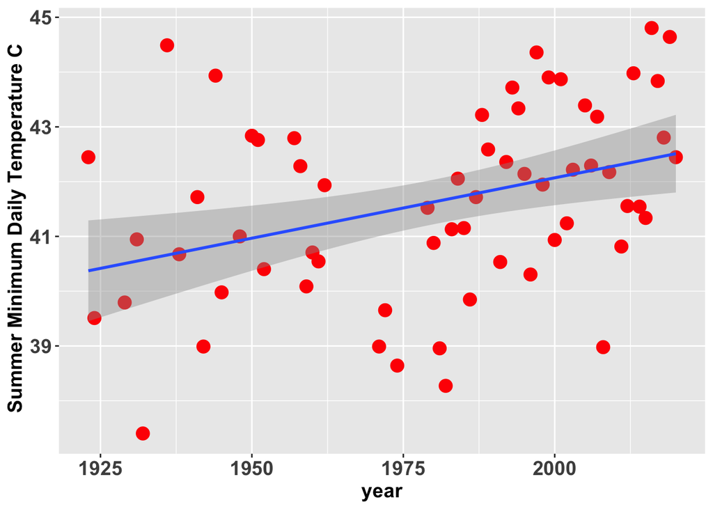

```r
# look only at summer
denali.summer = subset(denali_data.byseason, denali_data.byseason$season==3) %>%
  rename(year = 1)
tmp=unique(denali.summer$year)
# denali.summer$wy = tmp[1:length(tmp)-1]

ggplot(denali.summer, aes(x=year, y=tmin)) + stat_summary(fun.y="mean", geom="point", col="red", size=4)+theme(axis.text=element_text(size=14, face="bold"), axis.title=element_text(size=14, face="bold")) + geom_smooth(method="lm")+labs(y=" Summer Minimum Daily Temperature C")
```

```r
res=lm(tmax~year, data=denali.summer)
summary(res)
```

```
##
## Call:
## lm(formula = tmax ~ year, data = denali.summer)
##
## Residuals:
##     Min      1Q  Median      3Q     Max
## -5.6058 -1.6017 -0.3207  1.7019  6.9963
##
## Coefficients:
##              Estimate Std. Error t value Pr(>|t|)
## (Intercept) 61.434050  18.199514   3.376  0.00111 **
## year         0.001402   0.009216   0.152  0.87948
## ---
## Signif. codes:  0 '***' 0.001 '**' 0.01 '*' 0.05 '.' 0.1 ' ' 1
##
## Residual standard error: 2.391 on 85 degrees of freedom
##   (10 observations deleted due to missingness)
## Multiple R-squared:  0.000272,   Adjusted R-squared:  -0.01149
## F-statistic: 0.02313 on 1 and 85 DF,  p-value: 0.8795
```

```r
confint(res,"year", level=0.95)
```

```
##            2.5 %     97.5 %
## year -0.01692263 0.01972582
```

Notice how the trends in summer minimum temperature differ from the annual minimum temperature trend (Useful to do a Mann Kendall first in case trend is not linear)

Do we care? …Depends on the application!

EXTREMES

We already looked at the behavior of trends in some metrics - but here are a couple other examples of useful extremes.

1. Number of freezing days: select all days with temperatures below 32F

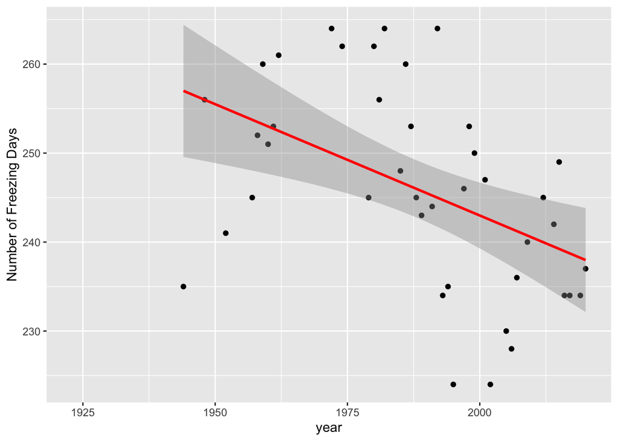

```r
denali_data$freeze = ifelse(denali_data$tmin <= 32, 1, 0)
denali_data.pk = denali_data %>% group_by(year(date)) %>% summarize(ndayfr=sum(freeze)) %>%
  rename(year = 1)

ggplot(denali_data.pk, aes(year, ndayfr))+geom_point()+labs(y="Number of Freezing Days") +
  stat_smooth(method="lm", col="red")
```

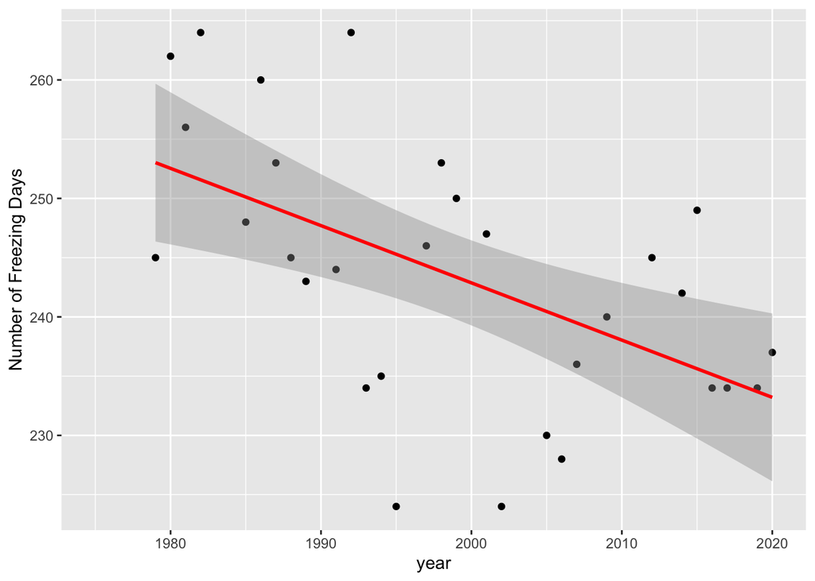

```r
# note - lm might not be appropriate for this one, but let's look at a subset of data

ggplot(subset(denali_data.pk, year %in% c(1975:2020)), aes(year, ndayfr))+geom_point()+labs(y="Number of Freezing Days") +
  stat_smooth(method="lm", col="red")
```

```r
#linear regression
lm_cold=lm(ndayfr~year, data=denali_data.pk)
summary(lm_cold)
```

```
##
## Call:
## lm(formula = ndayfr ~ year, data = denali_data.pk)
##
## Residuals:
##      Min       1Q   Median       3Q      Max
## -21.9975  -4.9816  -0.7332   6.7646  19.0131
##
## Coefficients:
##              Estimate Std. Error t value Pr(>|t|)
## (Intercept) 743.42671  149.84857   4.961 1.42e-05 ***
## year         -0.25022    0.07537  -3.320  0.00196 **
## ---
## Signif. codes:  0 '***' 0.001 '**' 0.01 '*' 0.05 '.' 0.1 ' ' 1
##
## Residual standard error: 10.18 on 39 degrees of freedom
##   (57 observations deleted due to missingness)
## Multiple R-squared:  0.2203, Adjusted R-squared:  0.2003
## F-statistic: 11.02 on 1 and 39 DF,  p-value: 0.001962
```

```r
confint(lm_cold,"year", level=0.95)
```

```
##           2.5 %      97.5 %
## year -0.4026794 -0.09776216
```

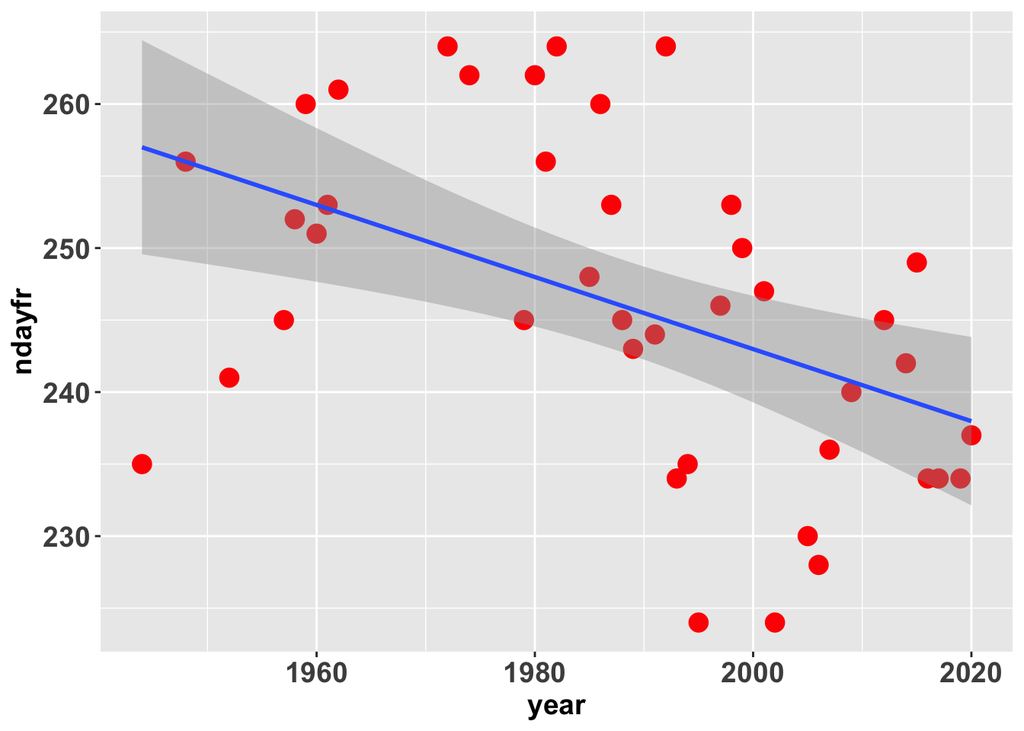

```r
ggplot(denali_data.pk, aes(x=year, y=ndayfr)) + stat_summary(fun.y="mean", geom="point", col="red", size=4)+theme(axis.text=element_text(size=14, face="bold"), axis.title=element_text(size=14, face="bold")) + geom_smooth(method="lm")
```

2. Hottest day of the year

Looking at the warm end of the temperature distribution, we can look for trends in the temperature during the hottest day of the year.

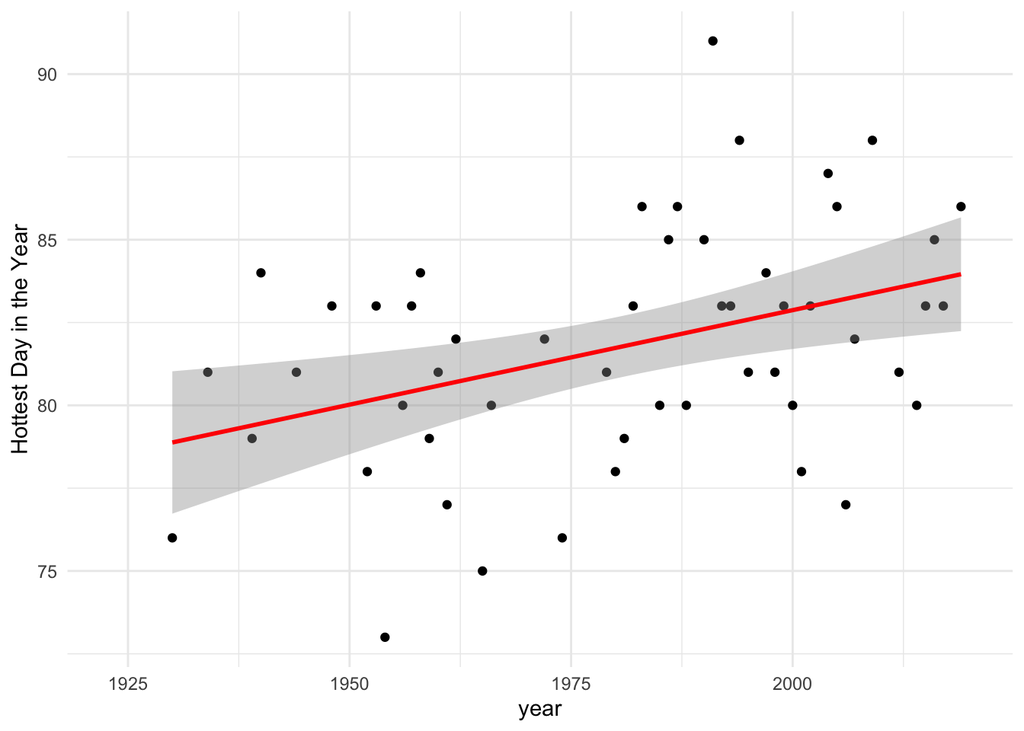

```r
denali.hot = denali_data %>% group_by(year(date)) %>% summarize(hotday=max(tmax)) %>%
  rename(year = 1)

ggplot(denali.hot, aes(year, hotday))+ geom_point()+labs(y="Hottest Day in the Year") +
  stat_smooth(method="lm", col="red") +
  theme_minimal()
```

```r
lm_hot=lm(hotday~year, data=denali.hot)
summary(lm_hot)
```

```
##
## Call:
## lm(formula = hotday ~ year, data = denali.hot)
##
## Residuals:
##     Min      1Q  Median      3Q     Max
## -7.2489 -2.1484  0.0978  2.6091  8.6398
##
## Coefficients:
##              Estimate Std. Error t value Pr(>|t|)
## (Intercept) -31.24631   37.55308  -0.832  0.40933
## year          0.05706    0.01896   3.010  0.00408 **
## ---
## Signif. codes:  0 '***' 0.001 '**' 0.01 '*' 0.05 '.' 0.1 ' ' 1
##
## Residual standard error: 3.309 on 50 degrees of freedom
##   (46 observations deleted due to missingness)
## Multiple R-squared:  0.1534, Adjusted R-squared:  0.1365
## F-statistic: 9.061 on 1 and 50 DF,  p-value: 0.004084
```

```r
confint(lm_hot,"year", level=0.95)
```

```
##           2.5 %     97.5 %
## year 0.01898697 0.09513304
```

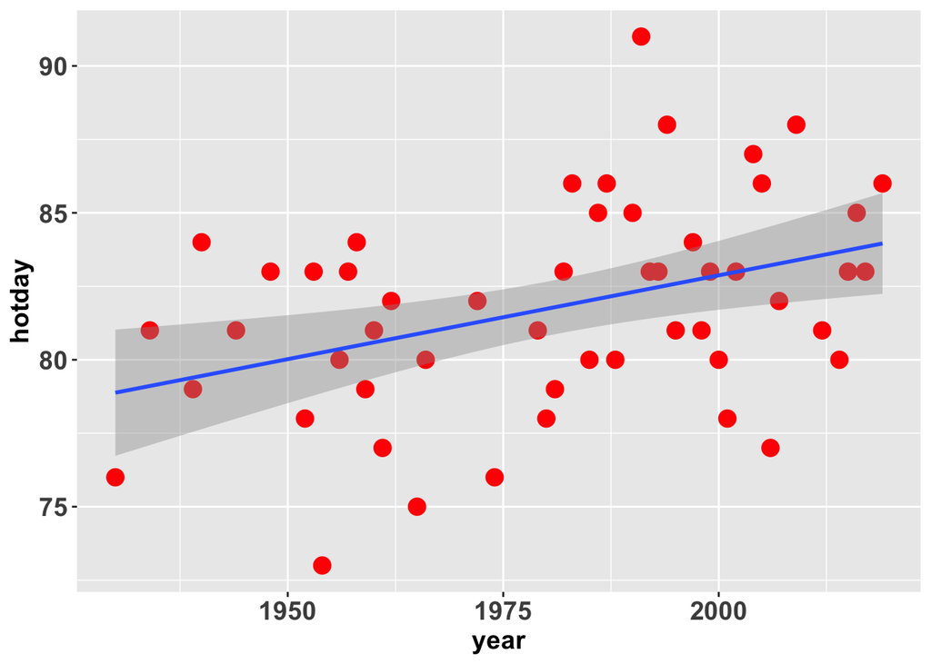

```r
ggplot(denali.hot, aes(x=year, y=hotday)) + stat_summary(fun.y="mean", geom="point", col="red", size=4)+theme(axis.text=element_text(size=14, face="bold"), axis.title=element_text(size=14, face="bold")) + geom_smooth(method="lm")
```

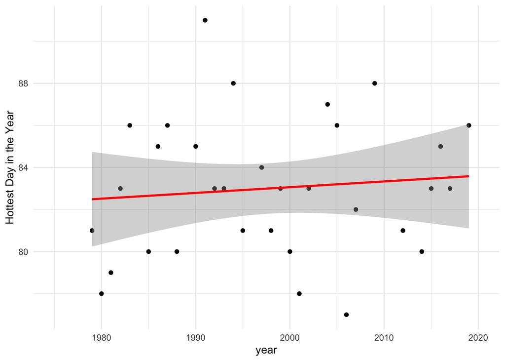

```r
# subset
ggplot(subset(denali.hot, year %in% c(1975:2020)), aes(year, hotday))+geom_point()+labs(y="Hottest Day in the Year") +
  stat_smooth(method="lm", col="red") +
  theme_minimal()
```

3. Return periods

In lecture, we discussed the concept of return periods and return levels. Here is how you calculate these things with real data!

Calculate the return period of 1 in daily precipitation

```r
denali_data$flood = ifelse(denali_data$prcp >= 1, 1, 0)
nyrs=length(unique(year(denali_data$date)))

retper=(nyrs+1)/sum(denali_data$flood,na.rm=TRUE)

retper
```

```
## [1] 0.7443609
```

4. statistical tests

```r
MannKendall(denali_data.pk$ndayfr)
```

```
## tau = -0.35, 2-sided pvalue =0.0015069
```

```r
MannKendall(denali.hot$hotday)
```

```
## tau = 0.259, 2-sided pvalue =0.0091388
```

```r
MannKendall(denali_agg$precip)
```

```
## tau = 0.214, 2-sided pvalue =0.0018563
```

(note: return *levels* are somewhat more complicated to calculate, since they require fitting the underlying distribution of the data… there are lots of resources out there if you need them though!)